# Assignment - Bayesian Networks

## Loading the Data

```r
data_assignment_3 <- read.csv(
  file = "C:/Users/smsab/Desktop/UCF/STA - 6704/dataset/Cleaned-Data_COVID.csv"
  )
data_assignment_3
```

| Fever | Tiredness | Dry.Cough | Difficulty.in.Breathing | Sore.Throat | None_Sympton | Pains | Nasal.Congestion | Runny.Nose | Diarrhea | None_Experiencing | Age_0.9 | Age_10.19 | Age_20.24 | Age_25.59 | Age_60. | Gender_Female | Gender_Male | Gender_Transgender | Severity_Mild | Severity_Moderate | Severity_None | Severity_Severe | Contact_Dont.Know | Contact_No | Contact_Yes | Country |
| --- | --- | --- | --- | --- | --- | --- | --- | --- | --- | --- | --- | --- | --- | --- | --- | --- | --- | --- | --- | --- | --- | --- | --- | --- | --- | --- |
| 1 | 1 | 1 | 1 | 1 | 0 | 1 | 1 | 1 | 1 | 0 | 1 | 0 | 0 | 0 | 0 | 0 | 1 | 0 | 1 | 0 | 0 | 0 | 0 | 0 | 1 | China |
| 1 | 1 | 1 | 1 | 1 | 0 | 1 | 1 | 1 | 1 | 0 | 1 | 0 | 0 | 0 | 0 | 0 | 1 | 0 | 1 | 0 | 0 | 0 | 0 | 1 | 0 | China |
| 1 | 1 | 1 | 1 | 1 | 0 | 1 | 1 | 1 | 1 | 0 | 1 | 0 | 0 | 0 | 0 | 0 | 1 | 0 | 1 | 0 | 0 | 0 | 1 | 0 | 0 | China |
| 1 | 1 | 1 | 1 | 1 | 0 | 1 | 1 | 1 | 1 | 0 | 1 | 0 | 0 | 0 | 0 | 0 | 1 | 0 | 0 | 1 | 0 | 0 | 0 | 0 | 1 | China |
| 1 | 1 | 1 | 1 | 1 | 0 | 1 | 1 | 1 | 1 | 0 | 1 | 0 | 0 | 0 | 0 | 0 | 1 | 0 | 0 | 1 | 0 | 0 | 0 | 1 | 0 | China |
| 1 | 1 | 1 | 1 | 1 | 0 | 1 | 1 | 1 | 1 | 0 | 1 | 0 | 0 | 0 | 0 | 0 | 1 | 0 | 0 | 1 | 0 | 0 | 1 | 0 | 0 | China |
| 1 | 1 | 1 | 1 | 1 | 0 | 1 | 1 | 1 | 1 | 0 | 1 | 0 | 0 | 0 | 0 | 0 | 1 | 0 | 0 | 0 | 0 | 1 | 0 | 0 | 1 | China |
| 1 | 1 | 1 | 1 | 1 | 0 | 1 | 1 | 1 | 1 | 0 | 1 | 0 | 0 | 0 | 0 | 0 | 1 | 0 | 0 | 0 | 0 | 1 | 0 | 1 | 0 | China |
| 1 | 1 | 1 | 1 | 1 | 0 | 1 | 1 | 1 | 1 | 0 | 1 | 0 | 0 | 0 | 0 | 0 | 1 | 0 | 0 | 0 | 0 | 1 | 1 | 0 | 0 | China |
| 1 | 1 | 1 | 1 | 1 | 0 | 1 | 1 | 1 | 1 | 0 | 1 | 0 | 0 | 0 | 0 | 0 | 1 | 0 | 0 | 0 | 1 | 0 | 0 | 0 | 1 | China |

[output cut: 990 more lines]

This COVID-19 Symptoms Checker dataset is from the Kaggle Repository and is based on the guidelines given by the World Health Organization and the Ministry of Health and Family Welfare, India. The dataset helps identify whether any person has coronavirus based on pre-defined standard symptoms. For this assignment, I have chosen a more suitable dataset for Bayesian networks, that would pertain to the analysis of causation between symptoms, age, and other factors that would show if for example a person has a certain symptom, are they more susceptible to be old, or have another symptom, or the severity of the disease based on factors. None_Sympton and None_Experiencing points to a patient having no top 5 symptoms and not experiencing any other symptoms respectively. For this analysis, the symptom variables used would be Fever, Tiredness, Dry.Cough, Difficulty.in.Breathing, and Sore.Throat, which are the top 5 symptoms of COVID-19 as specified by the WHO. Other symptoms that are used would be the Pains, Nasal.Congestion, Runny.Nose, and Diarrhea. Variables for age help us identify if the virus is truly severe to those who are older. Three genders are used: Male, Female, and Transgender. The severity for the virus is considered to be None, Mild, Moderate, and Severe. The contact tell us if the person has been in contact with someone with the virus. The country variable tells us which country the person visited, but for the purpose of this analysis, it will not be used.

# Preparing the dataset for bnlearn package to have all factor variables

Removing Country and making sure we have factor variables for Bayesian networks

```r
d <- subset(data_assignment_3, select = -c(Country))
summary(d)
```

```
     Fever          Tiredness     Dry.Cough      Difficulty.in.Breathing  Sore.Throat      None_Sympton        Pains        Nasal.Congestion   Runny.Nose
 Min.   :0.0000   Min.   :0.0   Min.   :0.0000   Min.   :0.0             Min.   :0.0000   Min.   :0.0000   Min.   :0.0000   Min.   :0.0000   Min.   :0.0000
 1st Qu.:0.0000   1st Qu.:0.0   1st Qu.:0.0000   1st Qu.:0.0             1st Qu.:0.0000   1st Qu.:0.0000   1st Qu.:0.0000   1st Qu.:0.0000   1st Qu.:0.0000
 Median :0.0000   Median :0.5   Median :1.0000   Median :0.5             Median :0.0000   Median :0.0000   Median :0.0000   Median :1.0000   Median :1.0000
 Mean   :0.3125   Mean   :0.5   Mean   :0.5625   Mean   :0.5             Mean   :0.3125   Mean   :0.0625   Mean   :0.3636   Mean   :0.5455   Mean   :0.5455
 3rd Qu.:1.0000   3rd Qu.:1.0   3rd Qu.:1.0000   3rd Qu.:1.0             3rd Qu.:1.0000   3rd Qu.:0.0000   3rd Qu.:1.0000   3rd Qu.:1.0000   3rd Qu.:1.0000
 Max.   :1.0000   Max.   :1.0   Max.   :1.0000   Max.   :1.0             Max.   :1.0000   Max.   :1.0000   Max.   :1.0000   Max.   :1.0000   Max.   :1.0000
    Diarrhea      None_Experiencing    Age_0.9      Age_10.19     Age_20.24     Age_25.59      Age_60.    Gender_Female     Gender_Male     Gender_Transgender
 Min.   :0.0000   Min.   :0.00000   Min.   :0.0   Min.   :0.0   Min.   :0.0   Min.   :0.0   Min.   :0.0   Min.   :0.0000   Min.   :0.0000   Min.   :0.0000
 1st Qu.:0.0000   1st Qu.:0.00000   1st Qu.:0.0   1st Qu.:0.0   1st Qu.:0.0   1st Qu.:0.0   1st Qu.:0.0   1st Qu.:0.0000   1st Qu.:0.0000   1st Qu.:0.0000
 Median :0.0000   Median :0.00000   Median :0.0   Median :0.0   Median :0.0   Median :0.0   Median :0.0   Median :0.0000   Median :0.0000   Median :0.0000
 Mean   :0.3636   Mean   :0.09091   Mean   :0.2   Mean   :0.2   Mean   :0.2   Mean   :0.2   Mean   :0.2   Mean   :0.3333   Mean   :0.3333   Mean   :0.3333
 3rd Qu.:1.0000   3rd Qu.:0.00000   3rd Qu.:0.0   3rd Qu.:0.0   3rd Qu.:0.0   3rd Qu.:0.0   3rd Qu.:0.0   3rd Qu.:1.0000   3rd Qu.:1.0000   3rd Qu.:1.0000
 Max.   :1.0000   Max.   :1.00000   Max.   :1.0   Max.   :1.0   Max.   :1.0   Max.   :1.0   Max.   :1.0   Max.   :1.0000   Max.   :1.0000   Max.   :1.0000
 Severity_Mild  Severity_Moderate Severity_None  Severity_Severe Contact_Dont.Know   Contact_No      Contact_Yes
 Min.   :0.00   Min.   :0.00      Min.   :0.00   Min.   :0.00    Min.   :0.0000    Min.   :0.0000   Min.   :0.0000
 1st Qu.:0.00   1st Qu.:0.00      1st Qu.:0.00   1st Qu.:0.00    1st Qu.:0.0000    1st Qu.:0.0000   1st Qu.:0.0000
 Median :0.00   Median :0.00      Median :0.00   Median :0.00    Median :0.0000    Median :0.0000   Median :0.0000
 Mean   :0.25   Mean   :0.25      Mean   :0.25   Mean   :0.25    Mean   :0.3333    Mean   :0.3333   Mean   :0.3333
 3rd Qu.:0.25   3rd Qu.:0.25      3rd Qu.:0.25   3rd Qu.:0.25    3rd Qu.:1.0000    3rd Qu.:1.0000   3rd Qu.:1.0000
 Max.   :1.00   Max.   :1.00      Max.   :1.00   Max.   :1.00    Max.   :1.0000    Max.   :1.0000   Max.   :1.0000
```

```r
for(j in 1:ncol(d)){
  d[,j] <- factor(as.numeric(d[,j]))}
summary(d)
```

```
 Fever      Tiredness  Dry.Cough  Difficulty.in.Breathing Sore.Throat None_Sympton Pains      Nasal.Congestion Runny.Nose Diarrhea   None_Experiencing
 0:217800   0:158400   0:138600   0:158400                0:217800    0:297000     0:201600   0:144000         0:144000   0:201600   0:288000
 1: 99000   1:158400   1:178200   1:158400                1: 99000    1: 19800     1:115200   1:172800         1:172800   1:115200   1: 28800
 Age_0.9    Age_10.19  Age_20.24  Age_25.59  Age_60.    Gender_Female Gender_Male Gender_Transgender Severity_Mild Severity_Moderate Severity_None
 0:253440   0:253440   0:253440   0:253440   0:253440   0:211200      0:211200    0:211200           0:237600      0:237600          0:237600
 1: 63360   1: 63360   1: 63360   1: 63360   1: 63360   1:105600      1:105600    1:105600           1: 79200      1: 79200          1: 79200
 Severity_Severe Contact_Dont.Know Contact_No Contact_Yes
 0:237600        0:211200          0:211200   0:211200
 1: 79200        1:105600          1:105600   1:105600
```

# Building the Bayesian Network Models

Constructing the Bayesian Models using a constraint-based, score-based, hybrid, and a local discovery algorithm. Using the the algorithms benchmarked by Dr. Smith with regards to computation time.

```r
require(bnlearn)
d_algorithms <- c("iamb.fdr", "hc", "h2pc", "aracne")
list_bnlearn <- list()
for(j in d_algorithms) try({
  list_bnlearn[[j]] <- do.call(
    what = j,
    args = list(x = d)
    )
  }
  )
```

[output not shown]

```r
list_bnlearn
```

```
$iamb.fdr

  Bayesian network learned via Constraint-based methods

  model:
    [partially directed graph]
  nodes:                                 26
  arcs:                                  44
    undirected arcs:                     34
    directed arcs:                       10
  average markov blanket size:           3.54
  average neighbourhood size:            3.38
  average branching factor:              0.38

  learning algorithm:                    IAMB-FDR
  conditional independence test:         Mutual Information (disc.)
  alpha threshold:                       0.05
  tests used in the learning procedure:  3968


$hc

  Bayesian network learned via Score-based methods

  model:
   [Dry.Cough][Pains][Age_0.9][Gender_Female][Severity_Mild][Contact_Dont.Know][None_Sympton|Dry.Cough][Runny.Nose|Pains][Age_60.|Age_0.9]
   [Gender_Transgender|Gender_Female][Severity_Severe|Severity_Mild][Contact_Yes|Contact_Dont.Know][Fever|None_Sympton][Nasal.Congestion|Pains:Runny.Nose]
   [Age_25.59|Age_0.9:Age_60.][Gender_Male|Gender_Female:Gender_Transgender][Severity_None|Severity_Mild:Severity_Severe]
   [Contact_No|Contact_Dont.Know:Contact_Yes][Tiredness|Fever:Dry.Cough:None_Sympton][Diarrhea|Pains:Nasal.Congestion:Runny.Nose]
   [Age_20.24|Age_0.9:Age_25.59:Age_60.][Severity_Moderate|Severity_Mild:Severity_None:Severity_Severe]
   [Difficulty.in.Breathing|Fever:Tiredness:Dry.Cough:None_Sympton][None_Experiencing|Pains:Nasal.Congestion:Runny.Nose:Diarrhea]
   [Age_10.19|Age_0.9:Age_20.24:Age_25.59:Age_60.][Sore.Throat|Fever:Tiredness:Dry.Cough:Difficulty.in.Breathing:None_Sympton]
  nodes:                                 26
  arcs:                                  46
    undirected arcs:                     0
    directed arcs:                       46
  average markov blanket size:           3.62
  average neighbourhood size:            3.54
  average branching factor:              1.77

```

[output cut: 40 more lines]

```
  Bayesian network learned via Pairwise Mutual Information methods

  model:
    [undirected graph]
  nodes:                                 26
  arcs:                                  309
    undirected arcs:                     309
    directed arcs:                       0
  average markov blanket size:           23.77
  average neighbourhood size:            23.77
  average branching factor:              0.00

  learning algorithm:                    ARACNE
  mutual information estimator:          Maximum Likelihood (disc.)
  tests used in the learning procedure:  325
```

The score-based algorithm hc() and the hybrid algorithm h2pc() produce directed graphs. Lets see if we can produce directed graphs with any other constraint-based and local discovery algorithms

```r
d_algorithms <- c("pc.stable", "gs", "iamb", "inter.iamb", "mmpc", "si.hiton.pc", "hpc", "chow.liu")
list2_bnlearn <- list()
for(j in d_algorithms) try({
  list2_bnlearn[[j]] <- do.call(
    what = j,
    args = list(x = d)
    )
  },silent = TRUE
  )
```

[output not shown]

```r
list2_bnlearn
```

```
$pc.stable

  Bayesian network learned via Constraint-based methods

  model:
    [partially directed graph]
  nodes:                                 26
  arcs:                                  44
    undirected arcs:                     34
    directed arcs:                       10
  average markov blanket size:           3.54
  average neighbourhood size:            3.38
  average branching factor:              0.38

  learning algorithm:                    PC (Stable)
  conditional independence test:         Mutual Information (disc.)
  alpha threshold:                       0.05
  tests used in the learning procedure:  988


$gs

  Bayesian network learned via Constraint-based methods

  model:
    [partially directed graph]
  nodes:                                 26
  arcs:                                  44
    undirected arcs:                     34
    directed arcs:                       10
  average markov blanket size:           3.54
  average neighbourhood size:            3.38
  average branching factor:              0.38

  learning algorithm:                    Grow-Shrink
  conditional independence test:         Mutual Information (disc.)
  alpha threshold:                       0.05
  tests used in the learning procedure:  2514


```

[output cut: 102 more lines]

```
  Bayesian network learned via Pairwise Mutual Information methods

  model:
    [undirected graph]
  nodes:                                 26
  arcs:                                  25
    undirected arcs:                     25
    directed arcs:                       0
  average markov blanket size:           1.92
  average neighbourhood size:            1.92
  average branching factor:              0.00

  learning algorithm:                    Chow-Liu
  mutual information estimator:          Maximum Likelihood (disc.)
  tests used in the learning procedure:  325
```

Since the other constraint-based algorithms and the local discovery algorithms do not produce a fully directed graph, lets proceed with the initial algorithms due to their benchmarked performance to save time: iamb.fdr(), hc(), h2pc(), and aracne().

# Scoring the Models

Since we do not have a lot of success with the learning of constraint based and local discovery algorithm, we can go on with finding the best model depending on the scoring type for the score-based and hybrid algorithms. Below, we will still try to score the constraint-based and local discovery algorithm. The selection of the model will depend on the type of scoring and the score itself for the algorithm. Testing of the available scores for discrete Bayesian networks for categorical variables will be performed. The measures that will be tested are loglik - which measures the log likelihood, meaning the goodness of fit of the model to the sample of the data. This is imperative, as we do want model that is a good fit, bic - which is a criterion for model selection amongst a set of models (lowest bic model is preferred) and it is partly based on the likelihood function, aic - which is an estimator of the prediction and informs about the quality of the model compared to other models in a set of models, bde - which is the logarithm of the Bayesian Dirichlet equivalent (uniform) score, a score equivalent Dirichlet posterior density and bds - the logarithm of the Bayesian Dirichlet sparse score, which is a sparsity-inducing Dirichlet posterior density and not score equivalent.

## bic

```r
d_algorithms <- c("iamb.fdr", "hc", "h2pc", "aracne")

M_score_bic <- list()
for (j in d_algorithms) try({
  M_score_bic[j] <- score(
    x=list_bnlearn[[j]],
    data = d,
    type = "bic"
  )
}
)
```

```
Error in network.score(x = x, data = data, type = type, ..., by.node = by.node,  :
  the graph is only partially directed.
Error in network.score(x = x, data = data, type = type, ..., by.node = by.node,  :
  the graph is only partially directed.
```

```r
M_score_bic <- data.frame(M_score_bic)
M_score_bic
```

| hc | h2pc |
| --- | --- |
| -3284101 | -3328486 |

## aic

```r
d_algorithms <- c("iamb.fdr", "hc", "h2pc", "aracne")

M_score_aic <- list()
for (j in d_algorithms) try({
  M_score_aic[j] <- score(
    x=list_bnlearn[[j]],
    data = d,
    type = "aic"
  )
}
)
```

```
Error in network.score(x = x, data = data, type = type, ..., by.node = by.node,  :
  the graph is only partially directed.
Error in network.score(x = x, data = data, type = type, ..., by.node = by.node,  :
  the graph is only partially directed.
```

```r
M_score_aic <- data.frame(M_score_aic)
M_score_aic
```

| hc | h2pc |
| --- | --- |
| -3283290 | -3327803 |

## loglik

```r
d_algorithms <- c("iamb.fdr", "hc", "h2pc", "aracne")

M_score_loglik <- list()
for (j in d_algorithms) try({
  M_score_loglik[j] <- score(
    x=list_bnlearn[[j]],
    data = d,
    type = "loglik"
  )
}
)
```

```
Error in network.score(x = x, data = data, type = type, ..., by.node = by.node,  :
  the graph is only partially directed.
Error in network.score(x = x, data = data, type = type, ..., by.node = by.node,  :
  the graph is only partially directed.
```

```r
M_score_loglik <- data.frame(M_score_loglik)
M_score_loglik
```

| hc | h2pc |
| --- | --- |
| -3283138 | -3327675 |

## bde

```r
d_algorithms <- c("iamb.fdr", "hc", "h2pc", "aracne")

M_score_bde <- list()
for (j in d_algorithms) try({
  M_score_bde[j] <- score(
    x=list_bnlearn[[j]],
    data = d,
    type = "bde"
  )
}
)
```

```
Error in network.score(x = x, data = data, type = type, ..., by.node = by.node,  :
  the graph is only partially directed.
Error in network.score(x = x, data = data, type = type, ..., by.node = by.node,  :
  the graph is only partially directed.
```

```r
M_score_bde <- data.frame(M_score_bde)
M_score_bde
```

| hc | h2pc |
| --- | --- |
| -3283483 | -3328004 |

## bds

```r
d_algorithms <- c("iamb.fdr", "hc", "h2pc", "aracne")

M_score_bds <- list()
for (j in d_algorithms) try({
  M_score_bds[j] <- score(
    x=list_bnlearn[[j]],
    data = d,
    type = "bds"
  )
}
)
```

```
Error in network.score(x = x, data = data, type = type, ..., by.node = by.node,  :
  the graph is only partially directed.
Error in network.score(x = x, data = data, type = type, ..., by.node = by.node,  :
  the graph is only partially directed.
```

```r
M_score_bds <- data.frame(M_score_bds)
M_score_bds
```

| hc | h2pc |
| --- | --- |
| -3283493 | -3328016 |

## Model Score Comparison

```r
#Combining the scores in a table df
g <- rbind(M_score_bic,M_score_aic,M_score_loglik, M_score_bde, M_score_bds)
rownames(g) <- c("bic", "aic", "loglik", "bde", "bds")
g
```

|  | hc | h2pc |
| --- | --- | --- |
| bic | -3284101 | -3328486 |
| aic | -3283290 | -3327803 |
| loglik | -3283138 | -3327675 |
| bde | -3283483 | -3328004 |
| bds | -3283493 | -3328016 |

```r
#Formatting the table to see which algorithm performs better
h <- data.frame(t(g))
colnames(h) <- rownames(g)
h
```

|  | bic | aic | loglik | bde | bds |
| --- | --- | --- | --- | --- | --- |
| hc | -3284101 | -3283290 | -3283138 | -3283483 | -3283493 |
| h2pc | -3328486 | -3327803 | -3327675 | -3328004 | -3328016 |

```r
#Sorting largest to smallest in terms of performance of algorithms
sorted_h <- h[order(h$bic,h$aic,h$loglik,h$bde,h$bds),]
sorted_h
```

|  | bic | aic | loglik | bde | bds |
| --- | --- | --- | --- | --- | --- |
| h2pc | -3328486 | -3327803 | -3327675 | -3328004 | -3328016 |
| hc | -3284101 | -3283290 | -3283138 | -3283483 | -3283493 |

Now that we have scores for the algorithms sorted, we can see that hc() performed better according to all scoring types. The best model according to the table is hc(). All the scoring types show the same results according to the table.

```r
apply(sorted_h, 2, FUN=max)
```

```
     bic      aic   loglik      bde      bds
-3284101 -3283290 -3283138 -3283483 -3283493
```

# Visualizing the model hc()

## Setting the node and edge attributes

```r
#Node Attributes
hc_covid <- hc(d)
v_nodes <- nodes(hc_covid)
names(v_nodes) <- v_nodes
strength_covid <- arc.strength(
  x = hc_covid,
  data = d
)
n_nodes <- nnodes(hc_covid)

v_fillcolor <- viridis::viridis(n_nodes)
names(v_fillcolor) <- v_nodes

v_shape <- c(
  rep("circle",floor(n_nodes/3)),
  rep("ellipse",floor(n_nodes/3)),
  rep("box",n_nodes - 2*floor(n_nodes/3))
  )
names(v_shape) <- v_nodes

#Edge Attributes
v_edges <- paste0(strength_covid[,"from"],"~",
                  strength_covid[,"to"])
names(v_edges) <- v_edges

v_edgecolor <- v_fillcolor[strength_covid[,"from"]]
names(v_edgecolor) <- v_edges
```

## Plotting the model

```r
#Converting the bnlearn model to a graphNEL model
graphNEL_covid <- as.graphNEL(hc_covid)
```

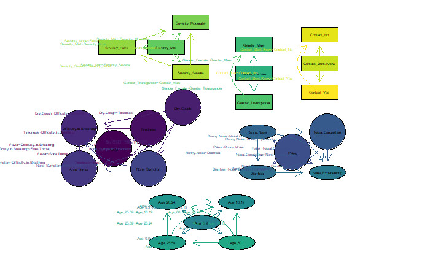

```r
Rgraphviz::plot(
  x = graphNEL_covid,
  y = "twopi",  attrs = list(),
  nodeAttrs = list(
    fillcolor = v_fillcolor,
    shape = v_shape
    ),
  edgeAttrs = list(
    label = v_edges,
    weight = graph::edgeWeights(graphNEL_covid),
    color = v_edgecolor,
    fontcolor = v_edgecolor
    )
  )
```

# Predict the target variable

## Predicting the target

For this analysis, since the bayesian model treats all the nodes as predictor and target, lets assume we are predicting the presence of the Nasal Congestion in a patient. Let’s predict whether the patient will have nasal congestion or not depending on the symptoms and other features that the patient might have.

```r
fit_model <- bn.fit(
  x = hc_covid,
  data = d
)
pred_table <- data.frame(pred = predict(fit_model, node = "Nasal.Congestion", data = d),actual = d$Nasal.Congestion)
summary(pred_table)
```

```
 pred       actual
 0:172442   0:144000
 1:144358   1:172800
```

## Evaluating Model Fit

```r
#Calculating AUC
AUC_model <- Metrics::auc(pred_table$actual,pred_table$pred)
print(paste0("AUC:", AUC_model))
```

```
[1] "AUC:0.641932291666667"
```

```r
#Calculating Model Accuracy
Accuracy_model <- Metrics::accuracy(pred_table$actual,pred_table$pred)
print(paste0("Accuracy: ", Accuracy_model))
```

```
[1] "Accuracy: 0.636729797979798"
```

```r
#Constructing the confusion matrix
confusion_matrix_model <- caret::confusionMatrix(pred_table$pred,pred_table$actual,"1")

cm <- data.frame(confusion_matrix_model$byClass)
cm
```

|  | confusion_matrix_model.byClass |
| --- | --- |
| Sensitivity | 0.5847049 |
| Specificity | 0.6991597 |
| Pos Pred Value | 0.6999058 |
| Neg Pred Value | 0.5838427 |
| Precision | 0.6999058 |
| Recall | 0.5847049 |
| F1 | 0.6371398 |
| Prevalence | 0.5454545 |
| Detection Rate | 0.3189299 |
| Detection Prevalence | 0.4556755 |

[output cut: 1 more lines]

If I was using this model at work, I would not use this for the analysis of this dataset. According to the evaluation scores above that show the model performance in prediction of nasal congestion, the scores are not that impressive. Let’s assume if the dataset only had features concerning symptoms, and the age features as well as the contact features were taken out, the prediction could be more accurate since age does not contribute towards a person having nasal congestion. However, since we are dealing with a graphical model, lets run a cross-validation to further see whether the model performs well without specifying a target:

```r
# Repeated 2-fold Cross-validation
cv_model <- bn.cv(
  data = d,
  bn = "hc",
  k = 2,
  runs = 2
)
cv_model
```

```
  k-fold cross-validation for Bayesian networks

  target learning algorithm:             Hill-Climbing
  number of folds:                       2
  loss function:                         Log-Likelihood Loss (disc.)
  number of runs:                        2
  average loss over the runs:            10.36363
  standard deviation of the loss:        7.64286e-05
```

The graphical model seems to perform well, however, I would not use this for prediction in a classification problem if we were trying to predict either a symptom, or severity. I would rather use a clustering technique or do a logistic regression for this kind of problem. This model would work well for a target prediction if we were only predicting presence of a disease looking at other diseases or maybe even age as features.